# Statistics

Assignment 2: Estimating your height z-score

# Instructions

Load the new data set on my [website](https://brianbeadle.github.io/statistics.html) that contains information on heights and weights.

The data set has 25,000 observations of two variables:

- `height`: Observed height (cm)
- `weight`: Observed weight (kg)

We will only work with the variable `height` for this assignment.

# Plot

First, generate the plot you see below. Use whatever colors you want and use the default number of bins (hint: Just remove the `bins = ""` command from the plot you generated in the first assignment)

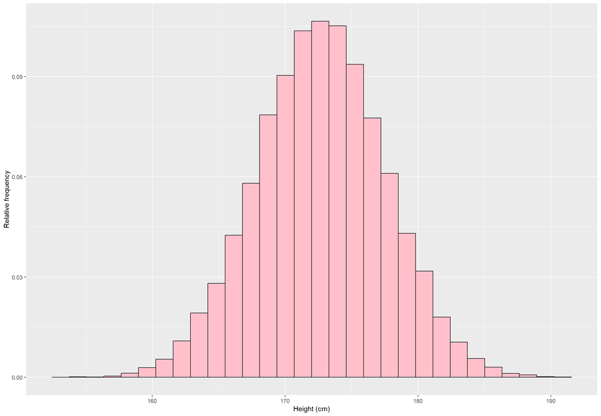

# Your z-score

To calculate the z-score for your height, you will first need to create objects that estimate the mean and standard deviation of the sample. You can create these by copying the following code:

```r
mu <- mean(d$height)
sigma <- sd(d$height)
```

Now look in your environment (top right panel of `RStudio` and you will see that there are objects in the Values window for mu and sigma).

**Task:** Now create another object that is the z-score of your height specifically. Call the object `z` and you will need your height (`x`) to estimate it.

The z-score equation is:

$$z = \frac{x-\mu}{\sigma}$$

and you can copy and paste the following code, and replace `x` with your height (in cm):

```r
z <- (x - mu) / sigma
```

After you calculate your z-score, display your score in the console by using the `print()` command. My z-score is the following:

```r
print(z)
```

```
## [1] 1.096729
```